# Assignment_2

Jordan Sands

18 November 2018

```r
require(dplyr)
library(caret)
```

## Cleaning

Let’s begin by splitting the data in to training, testing and validation sets. They will be split on the `classe` variable 60%, 20%, 20% respectively.

```r
training_data <- read.csv('pml-training.csv',stringsAsFactors = FALSE)


#create a 60% training 20% testing and  20% validation split
set.seed(48375)
inTrain <- createDataPartition(y=training_data$classe,p=0.6,list=F)

training <- training_data[inTrain,]
testing_and_validation <- training_data[-inTrain,]

inTest <- createDataPartition(y=testing_and_validation$classe,p=0.5,list=F)
testing <- testing_and_validation[inTest,]
validation <- testing_and_validation[-inTest,]
```

Taking a look at the training data we can see that some variables are coded as string when they should really be numeric or integers. We can also see a lot of missing data, (NAs).

```r
str(training)
```

[output not shown]

Now the data are cleaned, variables classes are converted and some variables are dropped. These are `raw_timestamp_part_1`, `raw_timestamp_part_2`, `cvtd_timestamp`, `user_name`, `X,new_window` and `num_window`. The data will be pre-prrocessed in a function so that test and validation can be treated the same way.

```r
pre_process_1 <- function(DF) {
    char_cols <- which(sapply(DF,is.character))
    num_char_cols <- length(char_cols)
    change_to_numeric <- char_cols[4:(num_char_cols-1)]

    DF[,change_to_numeric] <- lapply(DF[change_to_numeric],as.numeric)
    #ignore warnings

    DF$classe <- DF$classe %>% as.factor
    DF$new_window <- DF$new_window %>% as.factor

    ###drop data
    DF <- select(DF,-c(raw_timestamp_part_1,raw_timestamp_part_2,cvtd_timestamp,user_name,X,new_window,num_window))
    DF
}
```

Run the above code, passing it `training`

```r
training <- pre_process_1(training)
```

Some variables have many NA values, this is explored here

```r
na_counts <- sapply(training,function(col){mean(is.na(col))})
print(na_counts)
```

```
##                roll_belt               pitch_belt                 yaw_belt
##                0.0000000                0.0000000                0.0000000
##         total_accel_belt       kurtosis_roll_belt      kurtosis_picth_belt
##                0.0000000                0.9797045                0.9809783
##        kurtosis_yaw_belt       skewness_roll_belt     skewness_roll_belt.1
##                1.0000000                0.9796196                0.9809783
##        skewness_yaw_belt            max_roll_belt           max_picth_belt
##                1.0000000                0.9791101                0.9791101
##             max_yaw_belt            min_roll_belt           min_pitch_belt
##                0.9797045                0.9791101                0.9791101
##             min_yaw_belt      amplitude_roll_belt     amplitude_pitch_belt
##                0.9797045                0.9791101                0.9791101
##       amplitude_yaw_belt     var_total_accel_belt            avg_roll_belt
##                0.9797045                0.9791101                0.9791101
##         stddev_roll_belt            var_roll_belt           avg_pitch_belt
##                0.9791101                0.9791101                0.9791101
##        stddev_pitch_belt           var_pitch_belt             avg_yaw_belt
##                0.9791101                0.9791101                0.9791101
##          stddev_yaw_belt             var_yaw_belt             gyros_belt_x
##                0.9791101                0.9791101                0.0000000
##             gyros_belt_y             gyros_belt_z             accel_belt_x
##                0.0000000                0.0000000                0.0000000
##             accel_belt_y             accel_belt_z            magnet_belt_x
##                0.0000000                0.0000000                0.0000000
##            magnet_belt_y            magnet_belt_z                 roll_arm
##                0.0000000                0.0000000                0.0000000
##                pitch_arm                  yaw_arm          total_accel_arm
##                0.0000000                0.0000000                0.0000000
##            var_accel_arm             avg_roll_arm          stddev_roll_arm
##                0.9791101                0.9791101                0.9791101
##             var_roll_arm            avg_pitch_arm         stddev_pitch_arm
##                0.9791101                0.9791101                0.9791101
##            var_pitch_arm              avg_yaw_arm           stddev_yaw_arm
##                0.9791101                0.9791101                0.9791101
##              var_yaw_arm              gyros_arm_x              gyros_arm_y
##                0.9791101                0.0000000                0.0000000
##              gyros_arm_z              accel_arm_x              accel_arm_y
##                0.0000000                0.0000000                0.0000000
##              accel_arm_z             magnet_arm_x             magnet_arm_y
##                0.0000000                0.0000000                0.0000000
```

[output cut: 47 more lines]

```
##                0.9791101                0.9791101                0.9832711
##      total_accel_forearm        var_accel_forearm         avg_roll_forearm
##                0.0000000                0.9791101                0.9791101
##      stddev_roll_forearm         var_roll_forearm        avg_pitch_forearm
##                0.9791101                0.9791101                0.9791101
##     stddev_pitch_forearm        var_pitch_forearm          avg_yaw_forearm
##                0.9791101                0.9791101                0.9791101
##       stddev_yaw_forearm          var_yaw_forearm          gyros_forearm_x
##                0.9791101                0.9791101                0.0000000
##          gyros_forearm_y          gyros_forearm_z          accel_forearm_x
##                0.0000000                0.0000000                0.0000000
##          accel_forearm_y          accel_forearm_z         magnet_forearm_x
##                0.0000000                0.0000000                0.0000000
##         magnet_forearm_y         magnet_forearm_z                   classe
##                0.0000000                0.0000000                0.0000000
```

```r
more_than_90_perc_missing <- which(na_counts > 0.9)

training_refined <- training[,-more_than_90_perc_missing]
dim(training_refined)
```

```
## [1] 11776    53
```

After dropping some variables we can see there are 52 variables left.

## Exploration

let’s explore the relationship between the remaining 52 variables and `classe`. Below is a script to produce plots for the first 3 variables roll_belt, pitch_belt, yaw_belt

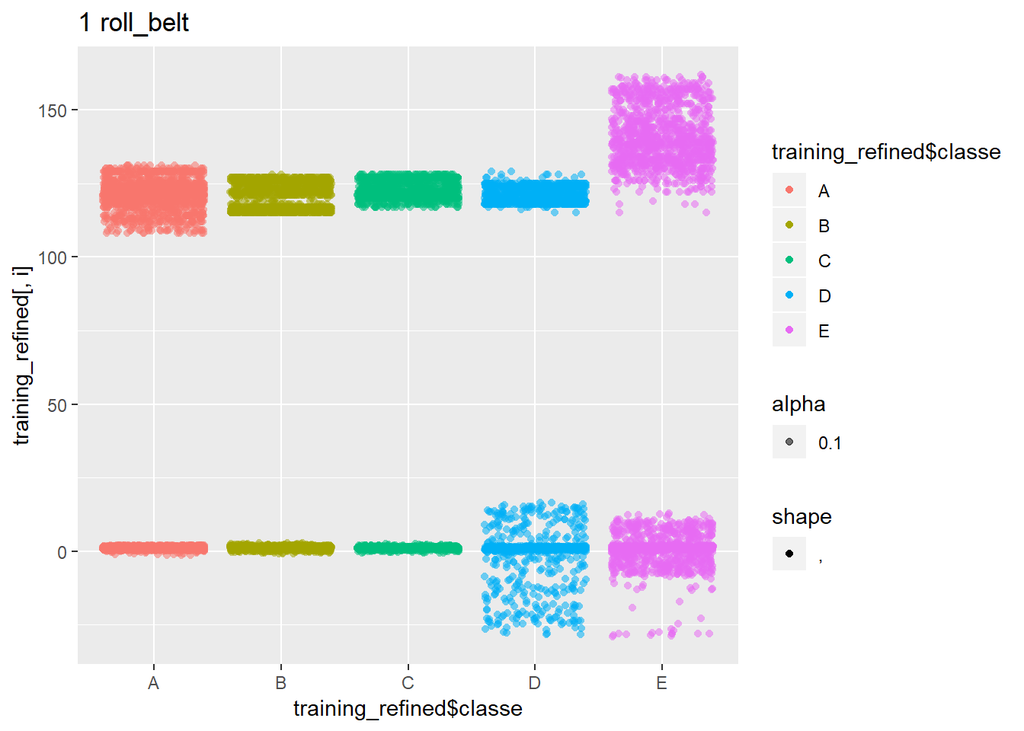

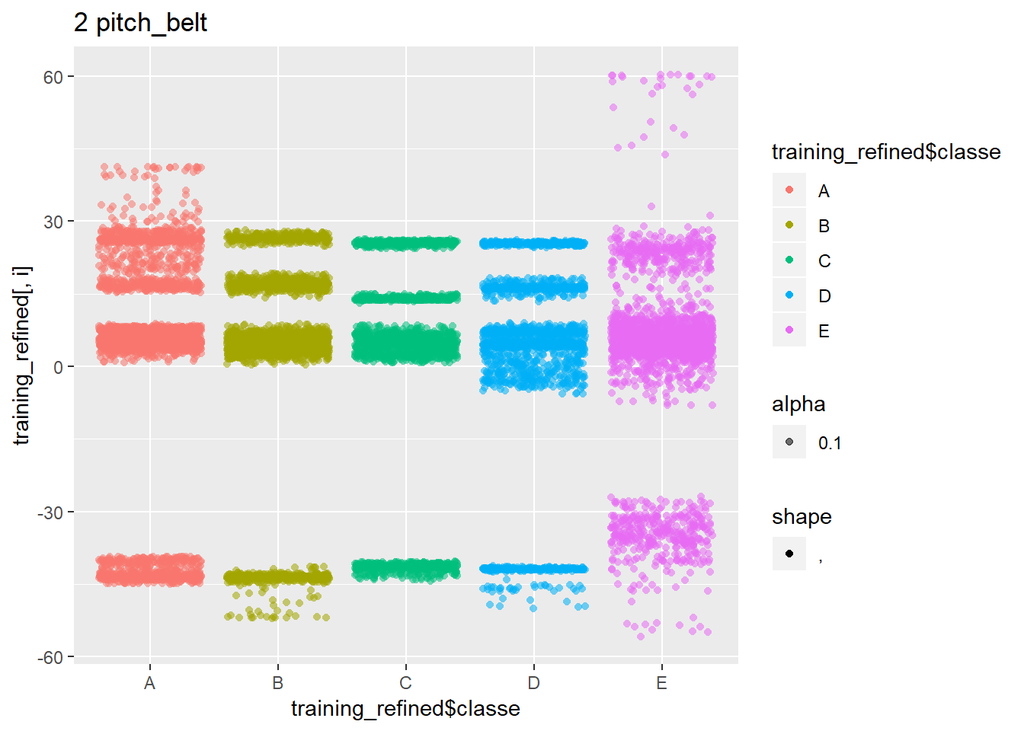

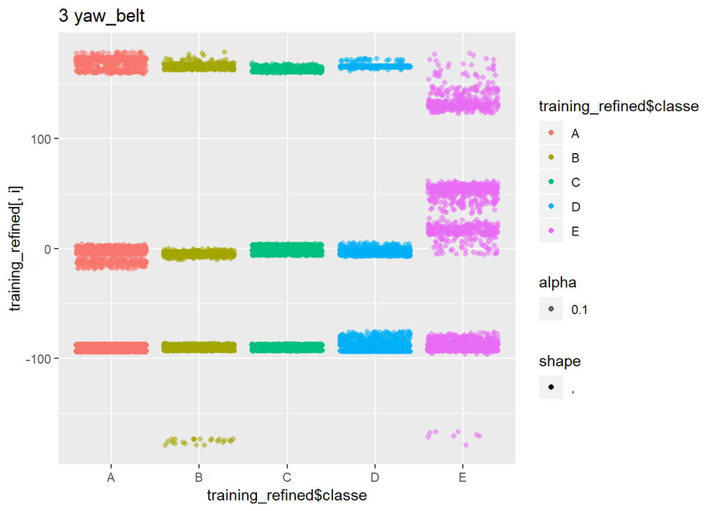

```r
for(i in 1:3) {
    qp <- qplot(training_refined$classe,training_refined[,i],geom='jitter',col=training_refined$classe,
                shape=',',alpha=0.1,main=paste(i,names(training_refined)[i]))
    print(qp)
}
```

With only 53 variables, the choice was made to select predictors by eye, below the data is further refined to include only these variables and the `classe` variable

```r
useful_vars <- c(1,2,3,4,5,6,7,8,9,10,11,12,13,16,17,19,21,22,23,24,27,28,30,31,32,33,34,35,36,37,38,39,40,41,42,43,44,45,46,48,49,50,51,52)
names(training_refined)[useful_vars]
```

```
##  [1] "roll_belt"            "pitch_belt"           "yaw_belt"
##  [4] "total_accel_belt"     "gyros_belt_x"         "gyros_belt_y"
##  [7] "gyros_belt_z"         "accel_belt_x"         "accel_belt_y"
## [10] "accel_belt_z"         "magnet_belt_x"        "magnet_belt_y"
## [13] "magnet_belt_z"        "yaw_arm"              "total_accel_arm"
## [16] "gyros_arm_y"          "accel_arm_x"          "accel_arm_y"
## [19] "accel_arm_z"          "magnet_arm_x"         "roll_dumbbell"
## [22] "pitch_dumbbell"       "total_accel_dumbbell" "gyros_dumbbell_x"
## [25] "gyros_dumbbell_y"     "gyros_dumbbell_z"     "accel_dumbbell_x"
## [28] "accel_dumbbell_y"     "accel_dumbbell_z"     "magnet_dumbbell_x"
## [31] "magnet_dumbbell_y"    "magnet_dumbbell_z"    "roll_forearm"
## [34] "pitch_forearm"        "yaw_forearm"          "total_accel_forearm"
## [37] "gyros_forearm_x"      "gyros_forearm_y"      "gyros_forearm_z"
## [40] "accel_forearm_y"      "accel_forearm_z"      "magnet_forearm_x"
## [43] "magnet_forearm_y"     "magnet_forearm_z"
```

```r
training_refined_2 <- select(training_refined,c(useful_vars,classe))
```

Create a second pre processing function that takes `training` and produces `training_refined_2`

```r
pre_process_2 <- function(DF) {
    select(DF[,-more_than_90_perc_missing],c(useful_vars,classe))
}

all(training_refined_2==pre_process_2(training))
```

```
## [1] TRUE
```

## Training

Three methods were chosen, random forrests, k nearest neighbours (knn) and classification trees.

```r
mod_knn <- train(classe ~ . ,data=training_refined_2,method='knn',tuneGrid=data.frame(k=1:3))
```

For the classification tree the `rpart` package is used, the complexity parameter, `cp` must be tuned to optimise the complexity of the resulting tree.

```r
mod_rpart <- train(classe ~ . ,data=training_refined_2,method='rpart',tuneGrid=data.frame(cp=seq(0.00000001,0.0001,0.00001)),trControl=trainControl(method='cv',number=25))
```

Finally a random forrest is fit, the optimal tuning parameter `mtry` is found by default in this case, without need to pass `train` a `tuneGrid` argument.

```r
mod_rf <- train(classe ~ . ,data=training_refined_2,method='rf')
```

didnt customise tuneGrid on this one but the mod_rf output suggests didnt need to

## Testing

```r
modList <- list(mod_knn=mod_knn,mod_rpart=mod_rpart,mod_rf=mod_rf)

testing <- testing %>% pre_process_1 %>% pre_process_2
```

[output not shown]

[output cut: 28 more lines]

[output not shown]

```r
predictions <- lapply(modList,function(mod) {predict(mod,testing)})
lapply(predictions,function(pred) {confusionMatrix(pred,testing$classe)})
```

```
## $mod_knn
## Confusion Matrix and Statistics
##
##           Reference
## Prediction    A    B    C    D    E
##          A 1084   22    7    8    0
##          B   13  708   12    2    9
##          C    8   17  646   20    9
##          D    8    8   14  607   11
##          E    3    4    5    6  692
##
## Overall Statistics
##
##                Accuracy : 0.9526
##                  95% CI : (0.9455, 0.959)
##     No Information Rate : 0.2845
##     P-Value [Acc > NIR] : <2e-16
##
##                   Kappa : 0.94
##  Mcnemar's Test P-Value : 0.1169
##
## Statistics by Class:
##
##                      Class: A Class: B Class: C Class: D Class: E
## Sensitivity            0.9713   0.9328   0.9444   0.9440   0.9598
## Specificity            0.9868   0.9886   0.9833   0.9875   0.9944
## Pos Pred Value         0.9670   0.9516   0.9229   0.9367   0.9746
## Neg Pred Value         0.9886   0.9840   0.9882   0.9890   0.9910
## Prevalence             0.2845   0.1935   0.1744   0.1639   0.1838
## Detection Rate         0.2763   0.1805   0.1647   0.1547   0.1764
## Detection Prevalence   0.2858   0.1897   0.1784   0.1652   0.1810
## Balanced Accuracy      0.9791   0.9607   0.9639   0.9658   0.9771
##
## $mod_rpart
## Confusion Matrix and Statistics
##
##           Reference
## Prediction    A    B    C    D    E
##          A 1075   26    6    5    4
##          B   24  669   25   13   14
```

[output cut: 43 more lines]

```
##
##                   Kappa : 0.9881
##  Mcnemar's Test P-Value : NA
##
## Statistics by Class:
##
##                      Class: A Class: B Class: C Class: D Class: E
## Sensitivity            0.9982   0.9829   0.9898   0.9829   0.9945
## Specificity            0.9964   0.9978   0.9954   0.9985   1.0000
## Pos Pred Value         0.9911   0.9907   0.9783   0.9922   1.0000
## Neg Pred Value         0.9993   0.9959   0.9978   0.9967   0.9988
## Prevalence             0.2845   0.1935   0.1744   0.1639   0.1838
## Detection Rate         0.2840   0.1902   0.1726   0.1611   0.1828
## Detection Prevalence   0.2865   0.1919   0.1764   0.1624   0.1828
## Balanced Accuracy      0.9973   0.9903   0.9926   0.9907   0.9972
```

## Validation

```r
validation <- validation %>% pre_process_1 %>% pre_process_2
```

[output not shown]

[output cut: 22 more lines]

[output not shown]

```r
confusionMatrix(predict(mod_rf,validation),validation$classe)
```

```
## Confusion Matrix and Statistics
##
##           Reference
## Prediction    A    B    C    D    E
##          A 1111    6    0    0    0
##          B    2  750    0    1    0
##          C    2    3  681   13    1
##          D    0    0    3  629    2
##          E    1    0    0    0  718
##
## Overall Statistics
##
##                Accuracy : 0.9913
##                  95% CI : (0.9879, 0.994)
##     No Information Rate : 0.2845
##     P-Value [Acc > NIR] : < 2.2e-16
##
##                   Kappa : 0.989
##  Mcnemar's Test P-Value : NA
##
## Statistics by Class:
##
##                      Class: A Class: B Class: C Class: D Class: E
## Sensitivity            0.9955   0.9881   0.9956   0.9782   0.9958
## Specificity            0.9979   0.9991   0.9941   0.9985   0.9997
## Pos Pred Value         0.9946   0.9960   0.9729   0.9921   0.9986
## Neg Pred Value         0.9982   0.9972   0.9991   0.9957   0.9991
## Prevalence             0.2845   0.1935   0.1744   0.1639   0.1838
## Detection Rate         0.2832   0.1912   0.1736   0.1603   0.1830
## Detection Prevalence   0.2847   0.1919   0.1784   0.1616   0.1833
## Balanced Accuracy      0.9967   0.9936   0.9949   0.9884   0.9978
```